# Embedding filtered content from Bioconductor software package vignettes

# Introduction

We would like to understand whether the text-embedding resource of OpenAI can be used to group packages on the basis of semantic similarity of content in vignettes.

# Crude embedding

Given a textual file “shvigs.csv” that has one row per vignette, a field ‘pkgname’ telling the name of a package in which the vignette is found, and a field ‘vigs’ containing the content of vignette (truncated to 30000 characters), this python program produces a CSV file with the text-embedding-3-large embedding of the text. The environment variable `OPENAI_API_TOKEN` must be set to a valid value.

```
import pandas as pd
import tiktoken

from utils.embeddings_utils import get_embedding

embedding_model = "text-embedding-3-large"
embedding_encoding = "cl100k_base" # check
max_tokens = 8000

input_datapath = "./shvigs.csv"

df = pd.read_csv(input_datapath, index_col=0)

df.head(2)

encoding = tiktoken.get_encoding(embedding_encoding)

df["n_tokens"] = df.vigs.apply(lambda x: len(encoding.encode(x)))
print(df["n_tokens"])
df.to_csv("lktok.csv")

df["embedding"] = df.vigs.apply(lambda x: get_embedding(x, model=embedding_model))
df.to_csv("shvigs1_emb_large.csv")
```

# Dimension reduction

## PCA

The `get_embedding` result is imported into R via `BiocOAI::extract_emb_matrix`, consisting of string manipulations and coercion to matrix.

```r
library(BiocOAI)
x = read.csv("shvigs1_emb_large.csv")
dd = data.frame(x[,1:4])
y = extract_emb_matrix("shvigs1_emb_large.csv", "embedding")
dim(y)
```

```
## [1]   89 3072
```

An approximate PCA is produced from the embedding.

```r
library(irlba)
```

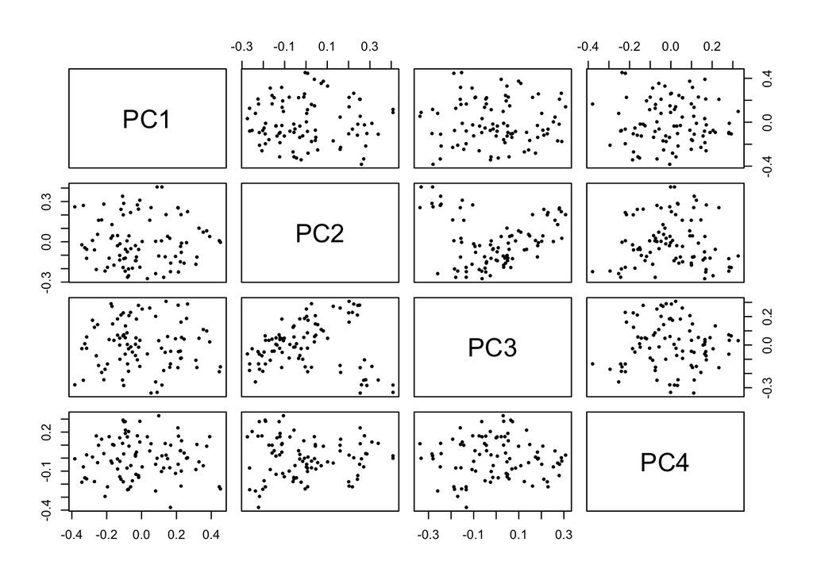

```r
set.seed(1234)
prc = prcomp_irlba(y, 10)
pairs(prc$x[,1:4], pch=19, cex=.4)
```

In the PC3:PC2 plane, some clustering is apparent?

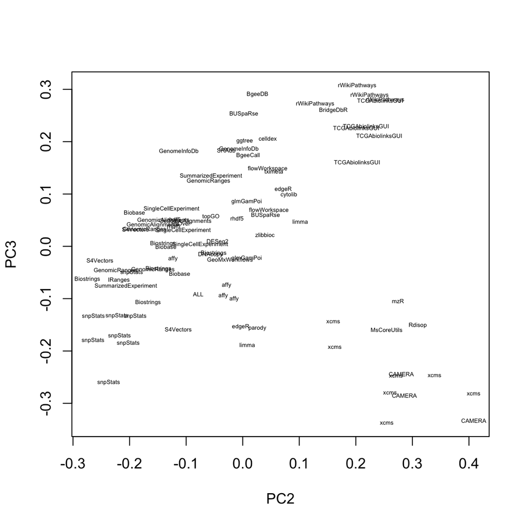

```r
plot(prc$x[,2:3], pch=" ")
text(prc$x[,2:3], labels=dd[,2], cex=.4)
```

## UMAP followed by k-means

In this section we want to visualize the partitioning of the UMAP projection of the embedding produced by k-means (9 clusters). Clustering after UMAP may be objectionable.

```r
library(spatstat)
library(uwot)
set.seed(1234)
uu = umap2(y, metric="cosine")
dd$umc1 = uu[,1]
dd$umc2 = uu[,2]
kk2 = kmeans(uu, 9)

Wp=owin(c(-2.5,3),c(-2.5,2.8)) # based on ranges of the umap coordinates

kkppp = as.ppp(kk2$centers, Wp)
kkpppdir = dirichlet(kkppp)
```

The visualization of the tesselation involves customization of plot operations, which do not appear to respect figure size controls in knitr.

We made a provisional short labeling of topics subjectively perceived to be present in tiles.

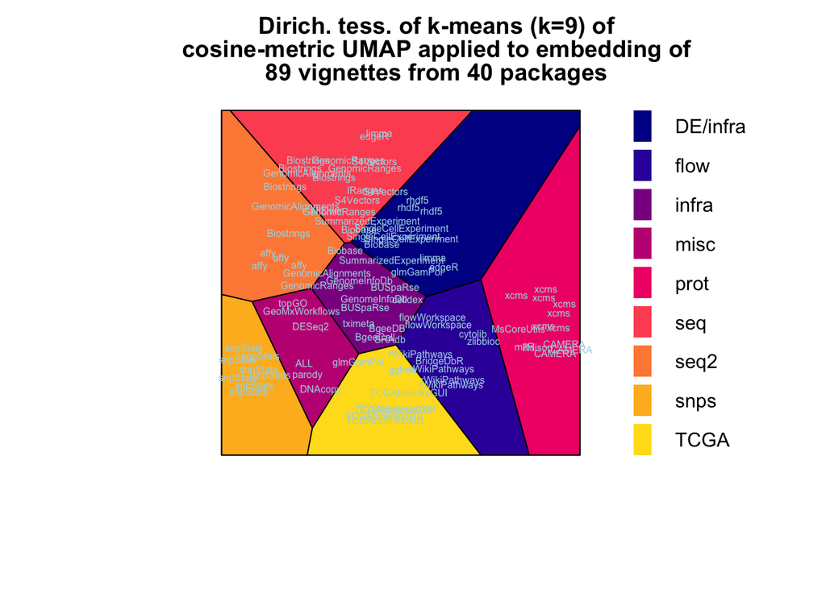

```r
thelabs = c("infra", "flow", "seq", "misc", "prot", "snps", "DE/infra", "TCGA", "seq2")
dtitle = paste("Dirich. tess. of k-means (k=9) of\n",
     sprintf("cosine-metric UMAP applied to embedding of \n%d vignettes from %d packages",
     nrow(dd), length(unique(dd[,2]))))
plot(kkpppdir, main=dtitle, labels=thelabs, do.col=TRUE, alpha=.5, values=thelabs, do.labels=FALSE)
text(uu, labels=dd[,2], cex=.5, col="lightblue")
```

The fact that DESeq2 is assigned to a tile distinct from limma and edgeR is unpleasant, but the vignette contents *as filtered* should be looked at more closely for available semantics.